# Next Word Prediction

# Project Overview

The main goal of the project is to build a shiny application that predicts the next word as we type a text.

The data provided by Coursera is the HC Corpora dataset, which contains entries from blogs, news, and twitter.

# Prediction Algorithm

- N-gram language model (unigram, bigram, trigram, and four-gram)
- Stupid backoff technique for prediction
- Dealing with unknown words: all words that appear only once are replaced in a model with a special word “#unk”
- Preprocessing:  
  - tokenize text into sentences  
  - remove all punctuation except apostrophe  
  - replace numbers with special word “#no”  
  - replacing english contractions (such as I’m) with full phrases (I am)

# Shiny Application

[Try it!](https://natasasdj.shinyapps.io/wordPred/)

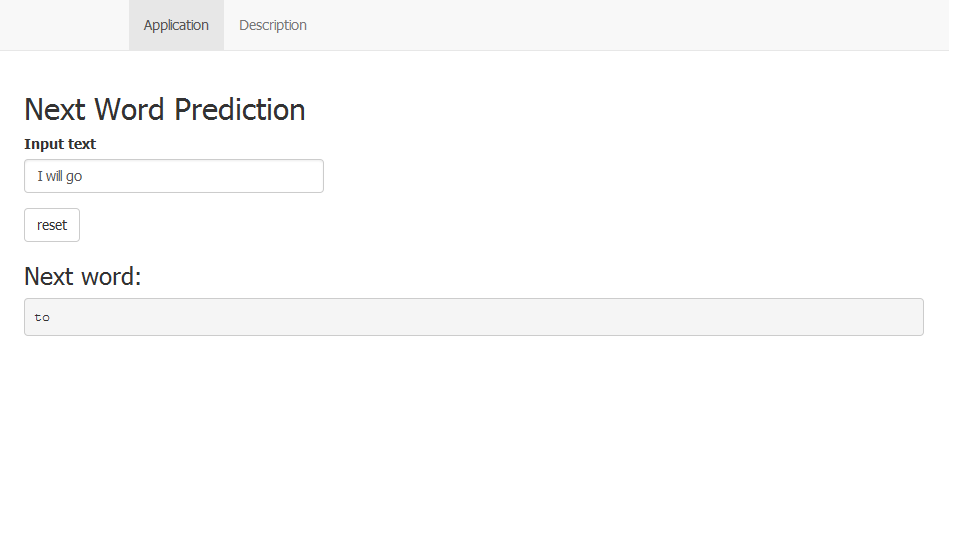

# Shiny Application - Description

This application allows a user to type a partial sentence and it predicts the next word following the user’s input.

- As a user is typing in the box ‘Input text’ , the next word is shown in the box ‘Next word’.  
  The next word is shown only when a user types the blank symbol.
- The input text is reset: with the button ‘reset’ or if a user types ‘.’